# Answers to [train data challenge](https://github.com/zahra-arjm/train_data/blob/main/README.md)

Zahra Arjmandi Lari, Tom Stafford

January 24, 2023

First importing the needed libraries. We need to install them in case they were not installed before (uncomment the commented lines if you get an error by running `library(package_name)`)

```r
#install.packages("dplyr")
#install.packages("ggplot2")
#install.packages("lubridate")
library("dplyr")
library("ggplot2")
library(lubridate)
```

Then, import the data:

```r
df <- read.csv('train_data.csv')
```

```r
head(df)
```

```
##       X train_id route arrival_time passenger_id       date
## 1 11025      t09     A        19:36      p478720 2022-11-23
## 2 11418      t10     A        20:41      p393143 2022-11-23
## 3   959      t09     A        08:47      p909240 2022-11-24
## 4 19401      t10     A        20:41      p717070 2022-11-22
## 5 49922      t07     E        05:34      p267647 2022-11-19
## 6 34329      t10     A        14:11      p630199 2022-11-20
```

And take a look at the data in each column:

```r
str(df)
```

```
## 'data.frame':    60168 obs. of  6 variables:
##  $ X           : int  11025 11418 959 19401 49922 34329 27102 37692 34456 17029 ...
##  $ train_id    : chr  "t09" "t10" "t09" "t10" ...
##  $ route       : chr  "A" "A" "A" "A" ...
##  $ arrival_time: chr  "19:36" "20:41" "08:47" "20:41" ...
##  $ passenger_id: chr  "p478720" "p393143" "p909240" "p717070" ...
##  $ date        : chr  "2022-11-23" "2022-11-23" "2022-11-24" "2022-11-22" ...
```

It seems most columns include categorical variable. Let’s see what are their unique values:

```r
unique(df$train_id)
```

```
##  [1] "t09" "t10" "t07" "t03" "t08" "t02" "t04" "t05" "t01" "t06"
```

```r
unique(df$route)
```

```
## [1] "A" "E" "C" "D" "B"
```

```r
unique(df$arrival_time)
```

```
##  [1] "19:36" "20:41" "08:47" "05:34" "14:11" "06:15" "13:06" "20:07" "12:02"
## [10] "23:35" "09:43" "06:37" "07:23" "15:16" "18:31" "16:27" "14:44" "07:42"
## [19] "23:42" "09:52" "09:12" "11:05" "22:17" "05:32" "12:49" "22:51" "16:21"
## [28] "11:01" "06:56" "14:38" "18:16" "17:26" "20:04" "13:11" "05:28" "16:39"
## [37] "10:57" "21:53" "22:33" "16:41" "21:46"
```

It seems like we have multiple trains which run in 5 routes and arrived to the destination at different time throughout the day.

Since we want to look at every single journey and none of the variables show us a specific joureny on their own, we need o combine them:

```r
journeys <- df %>%
  group_by(train_id, route, arrival_time, date) %>%
  summarise(passenger_count = n())
journeys
```

```
## # A tibble: 281 × 5
## # Groups:   train_id, route, arrival_time [41]
##    train_id route arrival_time date       passenger_count
##    <chr>    <chr> <chr>        <chr>                <int>
##  1 t01      D     06:56        2022-11-18              68
##  2 t01      D     06:56        2022-11-19             334
##  3 t01      D     06:56        2022-11-20             217
##  4 t01      D     06:56        2022-11-21              45
##  5 t01      D     06:56        2022-11-22              47
##  6 t01      D     06:56        2022-11-23              66
##  7 t01      D     06:56        2022-11-24             117
##  8 t01      D     22:33        2022-11-18              79
##  9 t01      D     22:33        2022-11-19             167
## 10 t01      D     22:33        2022-11-20             304
## # … with 271 more rows
```

Each row in `journeys` is a unique combination of `trin_id`, `route`, `arrival_time` and `date`. `passenger_count` variable shows the count of that specific combination, which is the number of passengers in that journey.

Now that we have number of passengers per journey, we can take a look at its distribution.

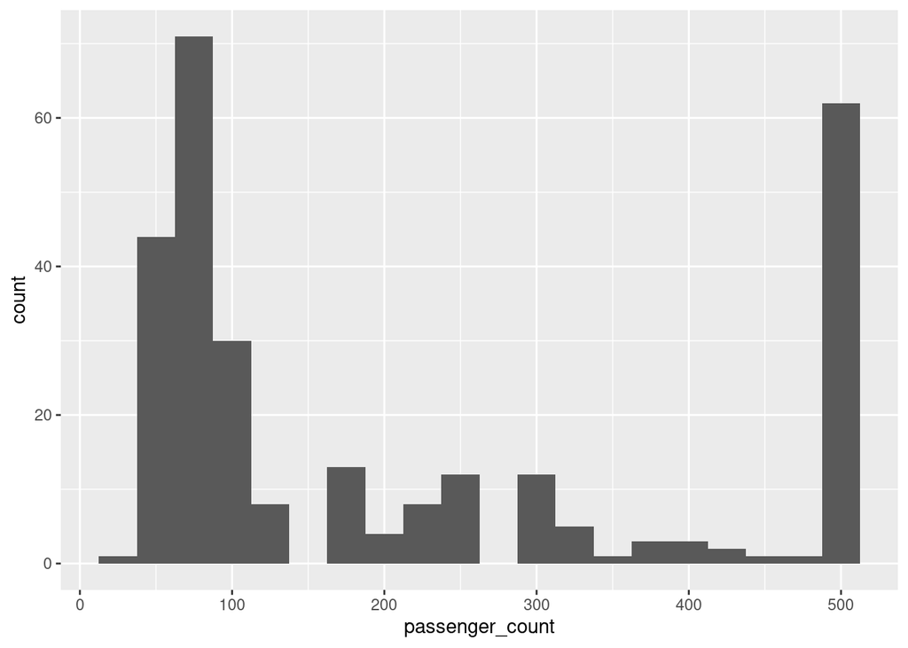

```r
ggplot(journeys, aes(x = passenger_count)) +
  geom_histogram(binwidth = 25)
```

There are a lot of trains which run near empty, and a lot of them which are full. Let’s extract summary statistics:

```r
summary(journeys$passenger_count)
```

```
##    Min. 1st Qu.  Median    Mean 3rd Qu.    Max.
##    37.0    73.0   102.0   214.1   376.0   500.0
```

based on the number of passengers per journey, we can see that the average number of passenger per journey is 214. Given that the maximum number of passengers in a journey is 500 (the capacity of a train) and the median of the passenger count is 102, more that half of the trains are more than half empty. In fact we can check out how many journeys run with less than 250 passengers.

```r
sum(journeys$passenger_count < 250)
```

```
## [1] 179
```

```r
sum(journeys$passenger_count < 250) / length(journeys$passenger_count)
```

```
## [1] 0.6370107
```

63% ! it seems that the argument of train companies are true about half train running half empty! But what about how passenger feel? Do passengers have a point when complaining about crowded trains?

Let’s add a column to the original data frame `df`, showing the number of passenger in each journey.

```r
df <- df %>%
  group_by(arrival_time, date) %>%
  mutate(passengerc_count = n())
head(df)
```

```
## # A tibble: 6 × 7
## # Groups:   arrival_time, date [6]
##       X train_id route arrival_time passenger_id date       passengerc_count
##   <int> <chr>    <chr> <chr>        <chr>        <chr>                 <int>
## 1 11025 t09      A     19:36        p478720      2022-11-23              500
## 2 11418 t10      A     20:41        p393143      2022-11-23              500
## 3   959 t09      A     08:47        p909240      2022-11-24              500
## 4 19401 t10      A     20:41        p717070      2022-11-22              500
## 5 49922 t07      E     05:34        p267647      2022-11-19              292
## 6 34329 t10      A     14:11        p630199      2022-11-20              260
```

And define a busy train to be 80% full.

```r
max_capacity = 500
busy_train_percent = .8
```

To calculate the frequency of passengers commuting with a “busy” train, we can write:

```r
sum(df$passengerc_count > busy_train_percent * max_capacity) /
  length(df$passengerc_count)
```

```
## [1] 0.5449242
```

54% of passengers are commuting with busy trains! It seems the commuters also have a point!

We can also make a bar plot from crowdedness of the trains, based on the time they have arrived.

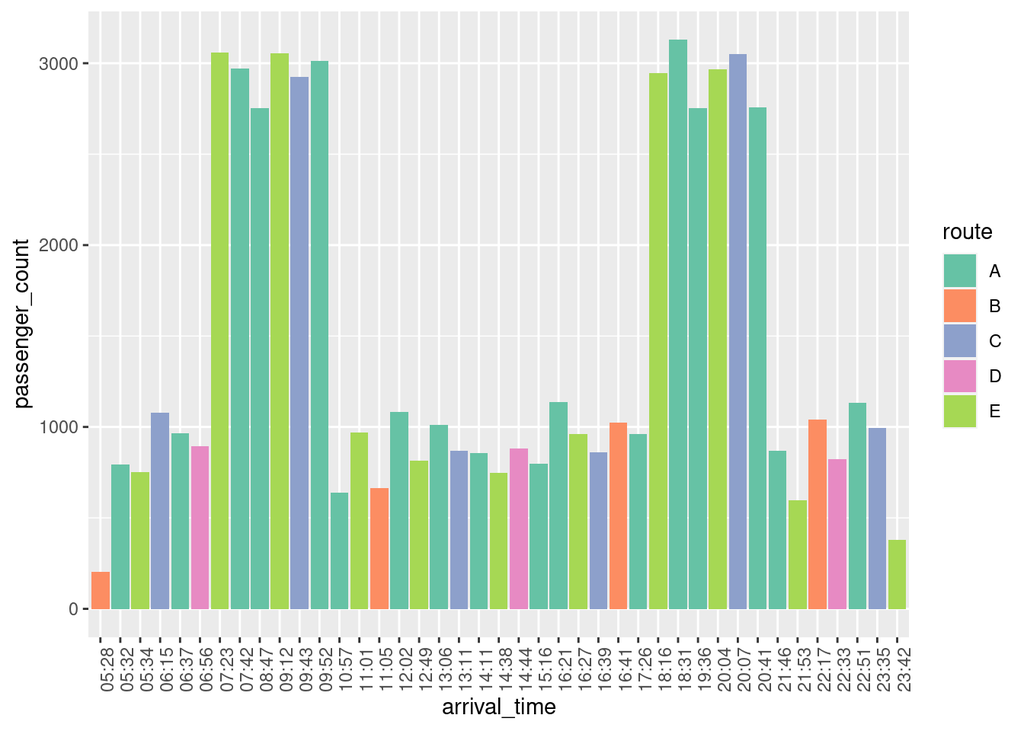

```r
ggplot(journeys, aes(x = arrival_time, y = passenger_count, fill = route)) +
  geom_bar(stat = "identity") +
  theme(axis.text.x = element_text(angle = 90, vjust = 1, hjust=1)) +
  scale_fill_brewer(palette="Set2")
```

See that there are two pick hours during the day. One in the morning and one at night. That’s why people feel they are commuting in busy trains. A lot of people commute during rush hours! Let’s check which dates we have data for.

```r
sort(unique(df$date))
```

```
## [1] "2022-11-18" "2022-11-19" "2022-11-20" "2022-11-21" "2022-11-22"
## [6] "2022-11-23" "2022-11-24"
```

We have 7 consequetive dates. But is the above pattern the same in the weekends and weekdays? Let’s try to separate the data from weekends!

The function `wday()` gives us which day of the week a date is.

```r
df$date[1]
```

```
## [1] "2022-11-23"
```

```r
wday(df$date[1], label=TRUE, abbr=FALSE)
```

```
## [1] Wednesday
## 7 Levels: Sunday < Monday < Tuesday < Wednesday < Thursday < ... < Saturday
```

We can also handle the days of the week numerically. It would make our lives easier in the code! It seems like the first day is Sunday, and the last day is Saturday. Let’s check if that is true for a date which is Saturday.

```r
day = "2022-11-19"
wday(day)
```

```
## [1] 7
```

Now, we need to make a column for weekdays in the `journeys` dataframe.

```r
journeys$week_day = wday(journeys$date)
head(journeys)
```

```
## # A tibble: 6 × 6
## # Groups:   train_id, route, arrival_time [1]
##   train_id route arrival_time date       passenger_count week_day
##   <chr>    <chr> <chr>        <chr>                <int>    <dbl>
## 1 t01      D     06:56        2022-11-18              68        6
## 2 t01      D     06:56        2022-11-19             334        7
## 3 t01      D     06:56        2022-11-20             217        1
## 4 t01      D     06:56        2022-11-21              45        2
## 5 t01      D     06:56        2022-11-22              47        3
## 6 t01      D     06:56        2022-11-23              66        4
```

Now we filter the weekends by slicing through the `journeys` dataframe.

```r
weekend_journeys = journeys[journeys$week_day == 1 | journeys$week_day == 7,]
head(weekend_journeys)
```

```
## # A tibble: 6 × 6
## # Groups:   train_id, route, arrival_time [3]
##   train_id route arrival_time date       passenger_count week_day
##   <chr>    <chr> <chr>        <chr>                <int>    <dbl>
## 1 t01      D     06:56        2022-11-19             334        7
## 2 t01      D     06:56        2022-11-20             217        1
## 3 t01      D     22:33        2022-11-19             167        7
## 4 t01      D     22:33        2022-11-20             304        1
## 5 t02      E     07:23        2022-11-19             167        7
## 6 t02      E     07:23        2022-11-20             391        1
```

And make a bar plot for the weekend journeys.

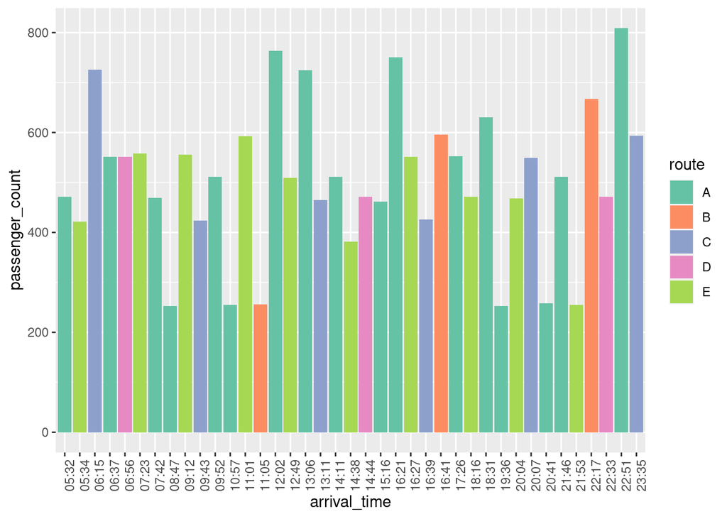

```r
ggplot(weekend_journeys, aes(x = arrival_time, y = passenger_count, fill = route)) +
  geom_bar(stat = "identity") +
  theme(axis.text.x = element_text(angle = 90, vjust = 1, hjust=1)) +
  scale_fill_brewer(palette="Set2")
```

No rush hour patterns! What about weekdays?

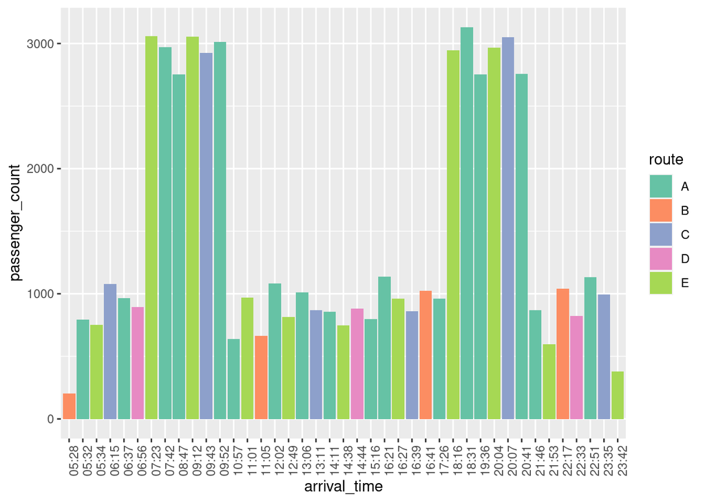

```r
weekday_journeys = journeys[journeys$week_day != 1 | journeys$week_day != 7,]
ggplot(weekday_journeys, aes(x = arrival_time, y = passenger_count, fill = route)) +
  geom_bar(stat = "identity") +
  theme(axis.text.x = element_text(angle = 90, vjust = 1, hjust=1)) +
  scale_fill_brewer(palette="Set2")
```

Hope you have enjoyed! :)